# mrgsolve Vignettes

Astellas Summer 2019

Metrum Research Group

# Meropenem Population PK

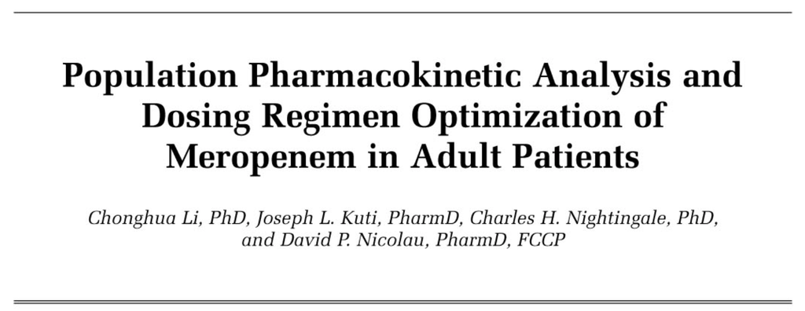

- Typical population PK model
- Simulate from EBE
- Visual predictive check
- Evaluate extended duration (3 hour) infusion compared to 0.5 hour
- Reference: src/ref/meropenem.pdf
- Model: model/meropenem_pk.cpp (and model/meropenem.cpp)

# EPO TIW/QW IV/SC and PTS

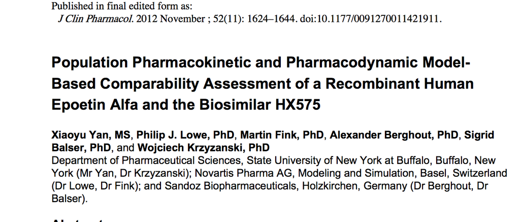

- Set up dosing regimens
- Evaluate probability of technical success for once weekly 40,000 IU dose administered SC and IV
- Reference: src/ref/epo.pdf
- Model: model/epo.cpp

# Palivizumab dose optimization

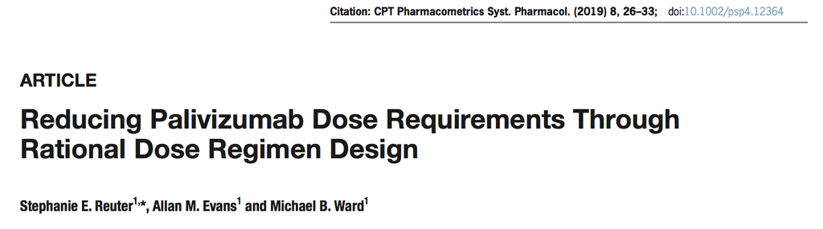

- Monoclonal antibody for respiratory syncytial virus (RSV)
- “One big simulation”
- Compare regimen in the label with other candidates to reduce total administered dose
- Reference: src/ref/palivizumab-sim.pdf
- Model: model/palivizumab.cpp

# Palivizumab PK modeling

[figure not shown]

- Reference: src/ref/palivizumab-model.pdf

# OATP drug-drug interaction

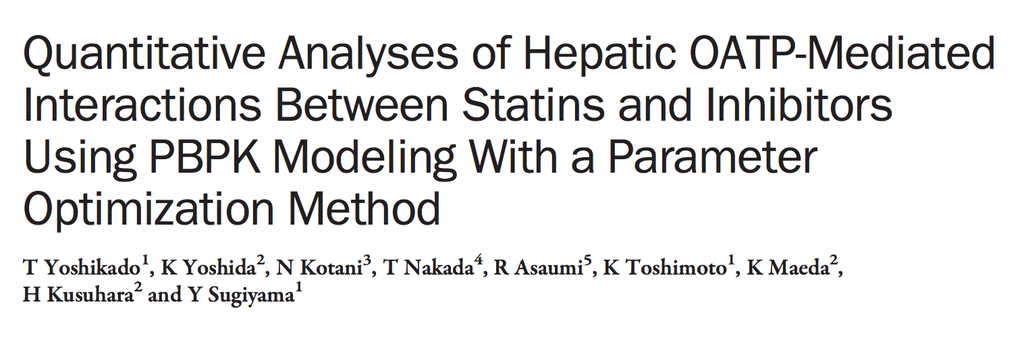

- Sensitivity analysis using PBPK model
- Parameter optimization
- Reference: src/ref/oatp-ddi.pdf
- Model: model/yoshikado.cpp
- Model: model/csa.cpp

# Fc-OPG for Osteoporosis

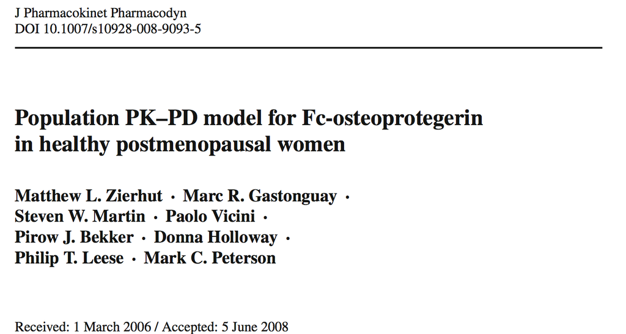

- Basic population PK/PD model (indirect response)
- Obtain median change from baseline 2-weeks after single dose with 95% CI interval
- Reference: src/ref/opg.pdf
- Model: model/opg.cpp

# Ciprofloxaxin PBPK

[figure not shown]

- Looking at ciprofloxacin exposure under different regimens in patients with and without renal dysfunction
- Use a PBPK model to simulate data presented in an independent publication
- Reference: src/ref/cipro-pk.pdf

# Ciprofloxacin PBPK

[figure not shown]

- Model: modeo/cipro.cpp

# Rifampicin PBPK

[figure not shown]

- Demonstrate auto-induction of rifampin clearance
- Explore DDI between rifampin and midazolam
- Reference: src/ref/rifampin.pdf
- Model: model/rifampicin.cpp
- Model: model/rifampicin_midazolam.cpp

# ERK Inhibition in Colorectal cancer

[figure not shown]

- Evaluate combination dosing regimens using QSP model and a virtual population
- Tumor dynamics under treatment with 1-4 different drugs
- Reference: src/ref/erk-inhibition.pdf
- Model: model/mapk.cpp